# 12-Disuguaglianza-di-Fano

## Notazioni preliminari

1. **Chain rule** $$ \begin{align} &H(X,Y) = H(X) + H(Y|X) = H(Y) + H(X|Y) \quad &(1) \\ \\ &\text{su spazio condizionato}\\ \\ &H(X,Y|Z ) = H(X|Z) + H(Y|X,Z) = H(Y|Z) + H(X|Y,Z) \quad &(2) \end{align} $$
2. **Diagrammi di Venn**

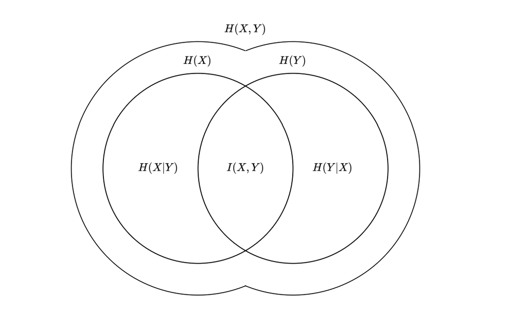

## Disuguaglianza di Fano

*Semanticamente*: Vogliamo spedire un carattere $X$ al ricevente $Y$ sul canale. Se il canale presenta **rumore** il carattere che abbiamo spedito potrà arrivare al ricevente con degli errori, di conseguenza il ricevente avrà un messaggio diverso dall'originale. Vogliamo quindi utilizzare una funzione $g(Y)$ che risalga al carattere originale $X$, e vogliamo calcolare qual è **la probabilità di errore** che questa funzione commette.

**Definizione:** Siano $X$ e $Y$ due variabili aleatorie che prendono valori in $\mathbb{X},\mathbb{Y}$ insiemi finiti. Sia $g: \mathbb{Y} \rightarrow \mathbb{X}$ una funzione che mappa i valori di $\mathbb{Y}$ nei valori di $\mathbb{X}$.

Sia **$P_e$** la proabilità di erroe nel **predire** $X$ quando uso $g$: $$ P_e = P(g(Y) \neq X) $$ Allora $$ P_e \geq \frac{H(X|Y) - 1}{\log |\mathbb{X}|} $$

### Dimostrazione

Introduciamo una variabile aleatoria *Bernoulliana* $E$ tale che $$ E = \begin{cases} &1 \quad \text{se} \quad g(Y) \neq X\\ &0 \quad \text{se} \quad g(Y) = X\\ \end{cases} $$ Per la **Chain rule** sugli spazi condizionati sappiamo che possiamo scrivere: $$ H(E,X|Y) = H(E|Y) + H(X|E,Y) \quad \text{oppure} \quad H(E,X|Y) = H(X|Y) + H(E|X,Y) $$ Possiamo fare le seguenti affermazioni:

1. $H(E|X,Y) = 0$, questo perchè conoscendo $X,Y$ posso calcolare $g(Y)$ e vedere se è uguale a $X$, e quindi sapere subito il valore di $E$ (quindi non ho bisogno di informazioni aggiuntive per descrivere $E$).
2. $H(E|Y) \leq H(E)$, questo lo si nota facendo il **diagramma di Venn**.

Consideriamo ora $H(X|E,Y)$ e lo riscriviamo come: $$ \begin{align} H(X|E,Y) &= P(E = 0) \cdot H(X|E=0,Y) + P(E= 1) \cdot H(X| E=1,Y) \quad &(1)\\ \\ &= (1 - P_e) \cdot H(X|E=0,Y) + P_e \cdot H(X| E=1,Y) \quad &(2)\\ \end{align} $$ Dal momento che $E$ è una *Bernoulliana* sappiamo che $P(E = 0) = 1 - P_e$ mentre $P(E = 1) = P_e$ dove $P_e$ è la probabilità di errore della funzione $g$. A questo punto però notiamo che $(1 - P_e) \cdot H(X|E=0,Y) = 0$ perchè se sappiamo che la variabile $E = 0$ vuol dire che non ci sono stati errori e che quindi $g(Y) = X$, di conseguenza l'entropia è pari a zero perchè non abbiamo informazioni aggiuntive per descrivere questo evento. $$ \begin{align} H(X|E,Y) &= 0 + P_e \cdot H(X| E=1,Y) \quad &(3)\\ \end{align} $$ Ora scriviamo $$ P_e \cdot H(X| E=1,Y) + H(E) \geq H(X|Y) + 0 $$ Sapendo che **l'entropia** ha come **upper bound** il $\log_Dm$ (dove $m$ è la cardinalità di $X$) quindi possiamo applicare una maggiorazione a $H(X| E=1,Y)\leq \log m - 1$, sottraiamo $-1$ perchè per $E = 1$ sto considerando tutti i valori di $X$ tranne quello corretto. Mentre $H(E)$ per una variabile aletoria *Bernoulliana* è sempre $H(E) \leq 1$. Riscrivendo abbiamo $$ \begin{align} &P_e \cdot \log \Big(m - 1\Big) + 1 \geq H(X|Y) \quad &(1)\\ &P_e \cdot \log \Big(m - 1\Big) \geq H(X|Y) - 1 \quad &(2)\\ \\ &\text{divido per il logaritmo}\\ \\ &P_e \geq \frac{H(X|Y) - 1}{\log \Big(|X| - 1\Big)} \quad &(3) \end{align} $$

Questo risultato ci permette di mostrare che l’entropia è anche un **lower bound per la probabilità di errore**, oltre che per il valore atteso delle lunghezze del codice. Questo lower bound però è modulato sulla grandezza della sorgente.